# Walmart_sales_correlation_analysis

## Walmart Sales Correlation Analysis

In this jupyter notebook we will be conducting a **correlation analysis**, attempting to detect relationships between weekly sales and macroeconomic variables such as **CPI** *(consumer price index)*, **fuel price** *(per gallon)*, **unemployment**, and a few others.

```python
#Importing relevant libraries
import pandas as pd
import numpy as np
import datetime as dt
import math

import matplotlib
import matplotlib.pyplot as plt
import seaborn as sns
```

```python
df = pd.read_csv("Walmart_sales.csv")
df.head()
```

|  | Store | Date | Weekly_Sales | Holiday_Flag | Temperature | Fuel_Price | CPI | Unemployment |
| --- | --- | --- | --- | --- | --- | --- | --- | --- |
| 0 | 1 | 05-02-2010 | 1643690.90 | 0 | 42.31 | 2.572 | 211.096358 | 8.106 |
| 1 | 1 | 12-02-2010 | 1641957.44 | 1 | 38.51 | 2.548 | 211.242170 | 8.106 |
| 2 | 1 | 19-02-2010 | 1611968.17 | 0 | 39.93 | 2.514 | 211.289143 | 8.106 |
| 3 | 1 | 26-02-2010 | 1409727.59 | 0 | 46.63 | 2.561 | 211.319643 | 8.106 |
| 4 | 1 | 05-03-2010 | 1554806.68 | 0 | 46.50 | 2.625 | 211.350143 | 8.106 |

## Data Cleaning and Preparation

```python
df.dtypes
```

```
Store             int64
Date             object
Weekly_Sales    float64
Holiday_Flag      int64
Temperature     float64
Fuel_Price      float64
CPI             float64
Unemployment    float64
dtype: object
```

```python
# Let's convert the Date column to a datetime datatype.
# In the US, dates are typically stored in the "%m-%d-%Y" format, and pd.to_datetime will not recognize the current format.
# Let's manipulate the order of fields so that month comes before day.
for i in range(df.index.max()+1):
    df.loc[i,"Date"] = dt.datetime.strptime(df.loc[i,"Date"], "%d-%m-%Y").strftime("%m-%d-%Y")
df.head()
```

|  | Store | Date | Weekly_Sales | Holiday_Flag | Temperature | Fuel_Price | CPI | Unemployment |
| --- | --- | --- | --- | --- | --- | --- | --- | --- |
| 0 | 1 | 02-05-2010 | 1643690.90 | 0 | 42.31 | 2.572 | 211.096358 | 8.106 |
| 1 | 1 | 02-12-2010 | 1641957.44 | 1 | 38.51 | 2.548 | 211.242170 | 8.106 |
| 2 | 1 | 02-19-2010 | 1611968.17 | 0 | 39.93 | 2.514 | 211.289143 | 8.106 |
| 3 | 1 | 02-26-2010 | 1409727.59 | 0 | 46.63 | 2.561 | 211.319643 | 8.106 |
| 4 | 1 | 03-05-2010 | 1554806.68 | 0 | 46.50 | 2.625 | 211.350143 | 8.106 |

```python
#Now that we have sucessfully converted our date format, let's convert the column's datatype to datetime.
df["Date"] = pd.to_datetime(df["Date"])
df.dtypes
```

```
Store                    int64
Date            datetime64[ns]
Weekly_Sales           float64
Holiday_Flag             int64
Temperature            float64
Fuel_Price             float64
CPI                    float64
Unemployment           float64
dtype: object
```

```python
#Checking for missing data (NULL/NaN/NoneType values)
for col in df.columns:
    pct_null = np.mean(df[col].isnull())
    qty_null = np.sum(df[col].isnull())
    print(f"{col} - {qty_null} NULLs | {round(pct_null*100,2)}% NULL")
```

```
Store - 0 NULLs | 0.0% NULL
Date - 0 NULLs | 0.0% NULL
Weekly_Sales - 0 NULLs | 0.0% NULL
Holiday_Flag - 0 NULLs | 0.0% NULL
Temperature - 0 NULLs | 0.0% NULL
Fuel_Price - 0 NULLs | 0.0% NULL
CPI - 0 NULLs | 0.0% NULL
Unemployment - 0 NULLs | 0.0% NULL
```

```python
#There are no missing (NULL/NA/NaN) values, so we do not need to fillna, dropna, etc.
```

```python
#Checking for duplicated data.
np.sum(df.duplicated())
```

```
0
```

```python
#There are no duplicated values, so we do not need to df.drop_duplicates().
```

```python
#We have several weeks of data in our dataframe.
#Let's ensure that we have:
#                   -7 days between each date recorded
#                   -All stores share the same dates

#First we will order the dates chronologically as data is currently out of chronological order.
df.sort_values(by=["Date"], inplace=True, ascending=True)

#Now let us reset the df's indices for effective row iteration and check for the correct time intervals.
df = df.reset_index()
#Removing extraneous index column.
df = df.drop(columns=['index'])

for i in range(df.index.max()):
    if (df.loc[i+1, "Date"]-df.loc[i, "Date"]).days == 7:
        continue
    elif (df.loc[i+1, "Date"]-df.loc[i, "Date"]).days == 0:
        continue
    else:
        print(f"ERROR: The dates at indices {i} and {i+1} are not 7 days apart!\n     {df.iloc[i,1]} and {df.iloc[i+1, 1]}.\n")
print("Dates are consistently populated.")
```

```
Dates are consistently populated.
```

```python
#Let's modify the unemployment column values to percentages.
df['Unemployment'] = df['Unemployment']/100
#Updating column names for clarity
df.rename(columns = {'Temperature':'Temperature(F)', 'Unemployment':'Unemployment_Rate'}, inplace = True)
df.head()
```

|  | Store | Date | Weekly_Sales | Holiday_Flag | Temperature(F) | Fuel_Price | CPI | Unemployment_Rate |
| --- | --- | --- | --- | --- | --- | --- | --- | --- |
| 0 | 1 | 2010-02-05 | 1643690.90 | 0 | 42.31 | 2.572 | 211.096358 | 0.08106 |
| 1 | 10 | 2010-02-05 | 2193048.75 | 0 | 54.34 | 2.962 | 126.442065 | 0.09765 |
| 2 | 37 | 2010-02-05 | 536006.73 | 0 | 45.97 | 2.572 | 209.852966 | 0.08554 |
| 3 | 17 | 2010-02-05 | 789036.02 | 0 | 23.11 | 2.666 | 126.442065 | 0.06548 |
| 4 | 30 | 2010-02-05 | 465108.52 | 0 | 39.05 | 2.572 | 210.752605 | 0.08324 |

## Correlation Analysis

```
<function matplotlib.pyplot.show(close=None, block=None)>
```

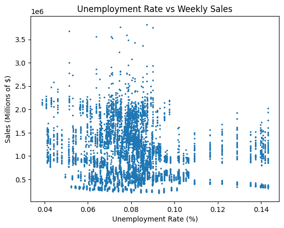

```python
#Beginning correlation testing.
plt.scatter(x=df['Unemployment_Rate'], y=df['Weekly_Sales'], s=2)
plt.title('Unemployment Rate vs Weekly Sales')
plt.xlabel('Unemployment Rate (%)')
plt.ylabel('Sales (Millions of $)')
plt.show
#plt.scatter(x=df['Unemployment_Rate'], y=df['Weekly_Sales'])
#plt.title('Unemployment Rate vs. Weekly Sales')
```

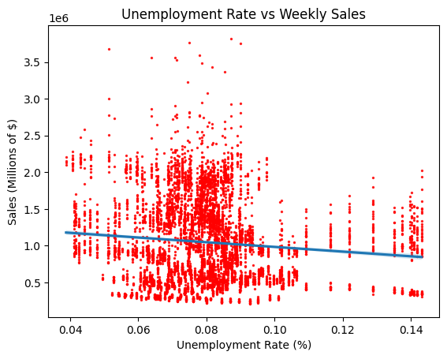

```python
#Now let's add a trendline to the scatter plot.
sns.regplot(x='Unemployment_Rate', y='Weekly_Sales', data=df, scatter_kws={'s':2, 'color':'red'})
plt.title('Unemployment Rate vs Weekly Sales')
plt.xlabel('Unemployment Rate (%)')
plt.ylabel('Sales (Millions of $)')
```

```python
#Let's visualize the correlation coefficients between variables.
df.corr(method='pearson')
```

|  | Store | Date | Weekly_Sales | Holiday_Flag | Temperature(F) | Fuel_Price | CPI | Unemployment_Rate |
| --- | --- | --- | --- | --- | --- | --- | --- | --- |
| Store | 1.000000e+00 | 7.474637e-16 | -0.335332 | 1.637929e-16 | -0.022659 | 0.060023 | -0.209492 | 0.223531 |
| Date | 7.474637e-16 | 1.000000e+00 | 0.006949 | -1.328524e-02 | 0.145357 | 0.771444 | 0.077157 | -0.248203 |
| Weekly_Sales | -3.353320e-01 | 6.949360e-03 | 1.000000 | 3.689097e-02 | -0.063810 | 0.009464 | -0.072634 | -0.106176 |
| Holiday_Flag | 1.637929e-16 | -1.328524e-02 | 0.036891 | 1.000000e+00 | -0.155091 | -0.078347 | -0.002162 | 0.010960 |
| Temperature(F) | -2.265908e-02 | 1.453566e-01 | -0.063810 | -1.550913e-01 | 1.000000 | 0.144982 | 0.176888 | 0.101158 |
| Fuel_Price | 6.002295e-02 | 7.714439e-01 | 0.009464 | -7.834652e-02 | 0.144982 | 1.000000 | -0.170642 | -0.034684 |
| CPI | -2.094919e-01 | 7.715746e-02 | -0.072634 | -2.162091e-03 | 0.176888 | -0.170642 | 1.000000 | -0.302020 |
| Unemployment_Rate | 2.235313e-01 | -2.482029e-01 | -0.106176 | 1.096028e-02 | 0.101158 | -0.034684 | -0.302020 | 1.000000 |

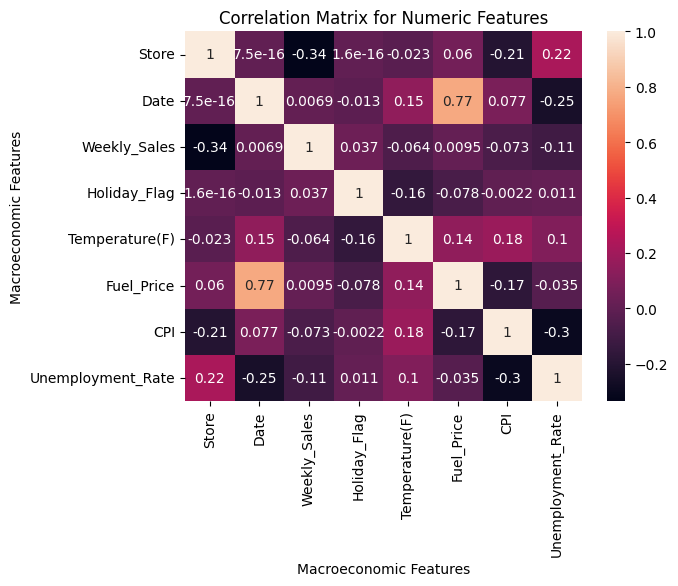

```python
correlation_matrix = df.corr(method='pearson')

sns.heatmap(correlation_matrix, annot=True)
plt.title('Correlation Matrix for Numeric Features')
plt.xlabel('Macroeconomic Features')
plt.ylabel('Macroeconomic Features')
```

```
<function matplotlib.pyplot.show(close=None, block=None)>
```

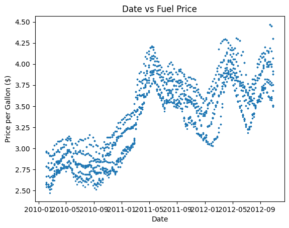

```python
#Since we see a strong correlation between Date and Fuel Price (0.77), let's plot these 2 variables.
plt.scatter(x=df['Date'], y=df['Fuel_Price'], s=2)
plt.title('Date vs Fuel Price')
plt.xlabel('Date')
plt.ylabel('Price per Gallon ($)')
plt.show
```

```python
df.loc[df.index.max(),'Date']-df.loc[0,'Date']
```

```
Timedelta('994 days 00:00:00')
```

### Looking at our correlation matrix, there are a few conclusions we can make.

#### *Across 995 days (timedelta accounts for n-1 days) and 45 different stores, we can observe that:*

- There are not any strong correlations between our given factors and weekly sales. Factors such as CPI and unemployment did not show any strong connection to weekly sales. This may be due to the fact that Walmart products are "needs" essential for human survival (food, drink, clothing, etc.)
- The strongest observed correlation is between average fuel price vs. date. This highlights the steep rise in gas prices seen in 2011 and 2012.
- Even with the significant increase in fuel prices, we can see that weekly sales remained somewhat consistent.
- We can conclude that Walmart sales are fairly resilient even in a volatile economy.